# Property_Price_Statistics_Analysis

## Introduction

This project analyzes property price data using statistical techniques. The goal of this analysis is to understand the distribution of property prices and identify the relationship between the number of rooms and the property price.

Various statistical measures such as mean, median, mode, standard deviation, and variance are used along with visualization techniques to better understand the dataset.

## Dataset Loading

import pandas as pd

## Dataset Information

The dataset information provides details about the number of rows, columns, and data types present in the dataset. This helps in understanding the structure of the dataset.

```python
df.info()
```

```
<class 'pandas.core.frame.DataFrame'>
RangeIndex: 13580 entries, 0 to 13579
Data columns (total 21 columns):
 #   Column         Non-Null Count  Dtype
---  ------         --------------  -----
 0   Suburb         13580 non-null  object
 1   Address        13580 non-null  object
 2   Rooms          13580 non-null  int64
 3   Type           13580 non-null  object
 4   Price          13580 non-null  float64
 5   Method         13580 non-null  object
 6   SellerG        13580 non-null  object
 7   Date           13580 non-null  object
 8   Distance       13580 non-null  float64
 9   Postcode       13580 non-null  float64
 10  Bedroom2       13580 non-null  float64
 11  Bathroom       13580 non-null  float64
 12  Car            13518 non-null  float64
 13  Landsize       13580 non-null  float64
 14  BuildingArea   7130 non-null   float64
 15  YearBuilt      8205 non-null   float64
 16  CouncilArea    12211 non-null  object
 17  Lattitude      13580 non-null  float64
 18  Longtitude     13580 non-null  float64
 19  Regionname     13580 non-null  object
 20  Propertycount  13580 non-null  float64
dtypes: float64(12), int64(1), object(8)
memory usage: 2.2+ MB
```

## Descriptive Statistics

Descriptive statistics help summarize the main characteristics of the dataset. It provides important measures such as count, mean, standard deviation, minimum, and maximum values.

```python
df.describe()
```

|  | Rooms | Price | Distance | Postcode | Bedroom2 | Bathroom | Car | Landsize | BuildingArea | YearBuilt | Lattitude | Longtitude | Propertycount |
| --- | --- | --- | --- | --- | --- | --- | --- | --- | --- | --- | --- | --- | --- |
| count | 13580.000000 | 1.358000e+04 | 13580.000000 | 13580.000000 | 13580.000000 | 13580.000000 | 13518.000000 | 13580.000000 | 7130.000000 | 8205.000000 | 13580.000000 | 13580.000000 | 13580.000000 |
| mean | 2.937997 | 1.075684e+06 | 10.137776 | 3105.301915 | 2.914728 | 1.534242 | 1.610075 | 558.416127 | 151.967650 | 1964.684217 | -37.809203 | 144.995216 | 7454.417378 |
| std | 0.955748 | 6.393107e+05 | 5.868725 | 90.676964 | 0.965921 | 0.691712 | 0.962634 | 3990.669241 | 541.014538 | 37.273762 | 0.079260 | 0.103916 | 4378.581772 |
| min | 1.000000 | 8.500000e+04 | 0.000000 | 3000.000000 | 0.000000 | 0.000000 | 0.000000 | 0.000000 | 0.000000 | 1196.000000 | -38.182550 | 144.431810 | 249.000000 |
| 25% | 2.000000 | 6.500000e+05 | 6.100000 | 3044.000000 | 2.000000 | 1.000000 | 1.000000 | 177.000000 | 93.000000 | 1940.000000 | -37.856822 | 144.929600 | 4380.000000 |
| 50% | 3.000000 | 9.030000e+05 | 9.200000 | 3084.000000 | 3.000000 | 1.000000 | 2.000000 | 440.000000 | 126.000000 | 1970.000000 | -37.802355 | 145.000100 | 6555.000000 |
| 75% | 3.000000 | 1.330000e+06 | 13.000000 | 3148.000000 | 3.000000 | 2.000000 | 2.000000 | 651.000000 | 174.000000 | 1999.000000 | -37.756400 | 145.058305 | 10331.000000 |
| max | 10.000000 | 9.000000e+06 | 48.100000 | 3977.000000 | 20.000000 | 8.000000 | 10.000000 | 433014.000000 | 44515.000000 | 2018.000000 | -37.408530 | 145.526350 | 21650.000000 |

```python
df.columns
```

```
Index(['Suburb', 'Address', 'Rooms', 'Type', 'Price', 'Method', 'SellerG',
       'Date', 'Distance', 'Postcode', 'Bedroom2', 'Bathroom', 'Car',
       'Landsize', 'BuildingArea', 'YearBuilt', 'CouncilArea', 'Lattitude',
       'Longtitude', 'Regionname', 'Propertycount'],
      dtype='object')
```

## Central Tendency Measures

Central tendency measures such as mean, median, and mode are used to understand the typical value of property prices in the dataset.

```python
df["Price"].mean()
```

```
np.float64(1075684.079455081)
```

```python
df["Price"].median()
```

```
903000.0
```

```python
df["Price"].mode()
```

```
0    1100000.0
Name: Price, dtype: float64
```

## Variability Measures

Standard deviation and variance are used to measure the spread or variability of property prices in the dataset.

```python
df["Price"].std()
```

```
639310.7242960194
```

```python
df["Price"].var()
```

```
408718202199.9009
```

## Histogram Visualization

A histogram is used to visualize the distribution of property prices in the dataset. It helps to understand how prices are spread across different ranges.

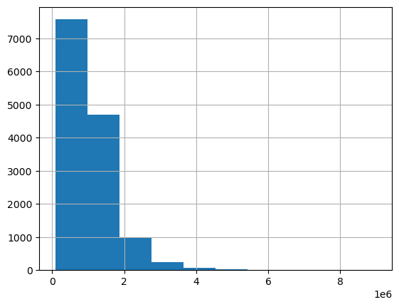

```python
import matplotlib.pyplot as plt

df["Price"].hist()
plt.show()
```

## Rooms vs Price Analysis

This analysis examines how the number of rooms in a property affects its price. Generally, properties with more rooms tend to have higher prices.

```python
df.groupby("Rooms")["Price"].mean()
```

```
Rooms
1     4.338245e+05
2     7.750812e+05
3     1.076081e+06
4     1.445282e+06
5     1.870260e+06
6     1.849366e+06
7     1.920700e+06
8     1.602750e+06
10    9.000000e+05
Name: Price, dtype: float64
```

## Scatter Plot Visualization

A scatter plot is used to visualize the relationship between the number of rooms and property prices.

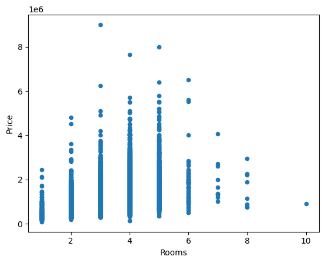

```python
df.plot.scatter(x="Rooms", y="Price")
plt.show()
```

## Hypothesis Testing

A one-sample t-test is performed to determine whether the average property price is significantly different from 1,000,000.

```python
from scipy import stats

stats.ttest_1samp(df["Price"], 1000000)
```

```
TtestResult(statistic=np.float64(13.795658278486819), pvalue=np.float64(5.277114189866881e-43), df=np.int64(13579))
```

## Conclusion

The analysis shows that the average property price in the dataset is approximately 1,075,684.

Properties with more rooms generally tend to have higher prices. The statistical test confirms that the average property price is significantly different from 1,000,000.